# Argentina Trust Index

Institutional

# Sampling

The survey was conducted by the Argentinian Red Cross Society (ARCS) in early 2023, covering questions around trust as part of the Community Trust Index project. With support of the Humanitarian Observatory, ARCS volunteers administered the survey, which focused on questions related to trust as part of the Building Trust project. The survey reached 3017 respondents across the country.

The sampling employed a convenient sampling approach focused on large parts of the country in Argentina. The coverage overall is 96% of the country, when looking at inhabitants at the province level.

*See metrics: Metrics*

## Geographic

Except for seven of the 23 provinces, all the provinces of Argentina were covered in the sample. Since the seven that were not included are not highly populated, 96% of the Argentinian population lived in the surveyed provinces in 2022, which is a very high coverage in the context of the Community Trust Index project. Besides some deviations, the sample was roughly allocated proportionally the population of the respective province.

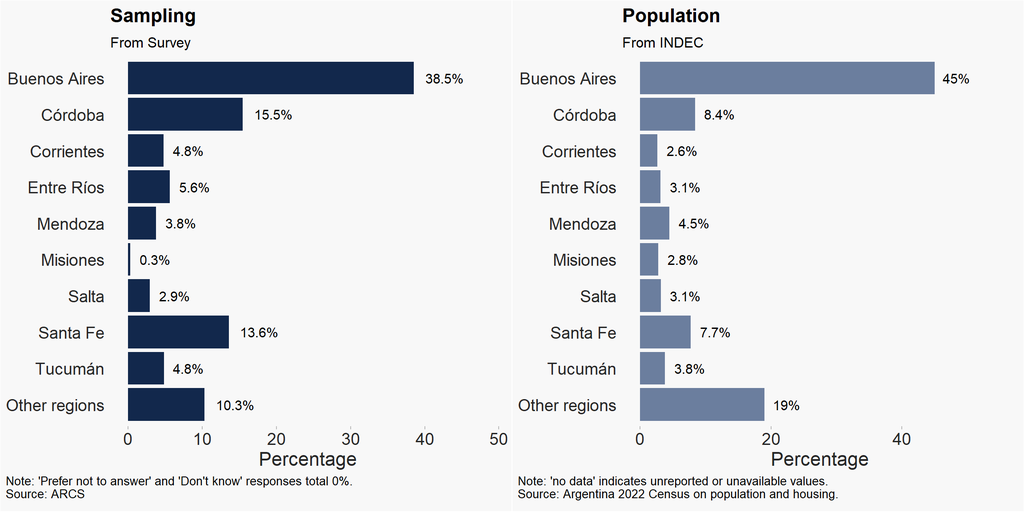

## Coverage

[interactive chart not shown]

## Gender and Age

For the following demographic data, we show the full data set including people who indicated to volunteered for the ARCS as well as those who benefited from the ARCS. Compared to the overall Argentinean population, in the sample women, especially younger women are over-represented, while elderly people are under-represented.

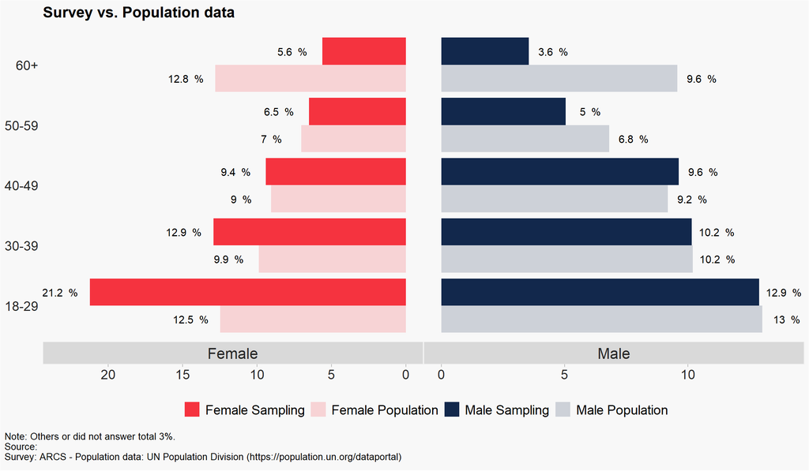

## Education

While we have not managed to access demographic data on education using the same levels as the survey, the survey demographics on education seem to correspond to expected values of the various levels of education in the overall population. However, there are notable exceptions. For instance, the percentage of individuals with university education in the survey is 11.5%, which is lower than the OECD population percentage of 23.4%. Additionally, the survey shows a higher percentage of individuals with secondary education (66%) compared to the OECD population (41.8%).

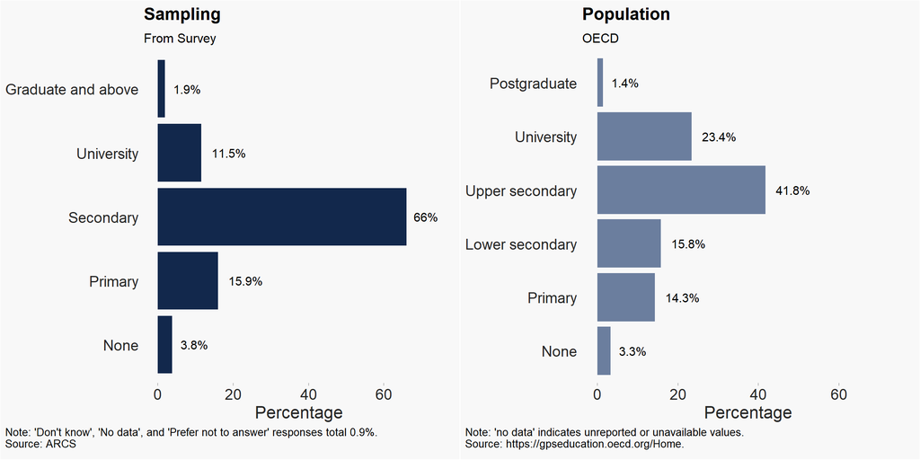

## Employment

The chart illustrates the distribution of employment statuses within the survey sampling. The categories include unemployed (9.1%), students (10.5%), part-time or full-time employment (43.5%), job seekers (9.8%), and informal employment (26.9%).

Notably, full-time students, who constitute approximately 10.5% of the survey population, are over-represented compared to the overall Argentinian population aged above 18, where the student population was close to 6% in 2020. This discrepancy highlights the need for a weighting procedure to adjust and correct this over-representation when calculating the weighted overall results. This adjustment will ensure that the survey results more accurately reflect the broader population demographics.

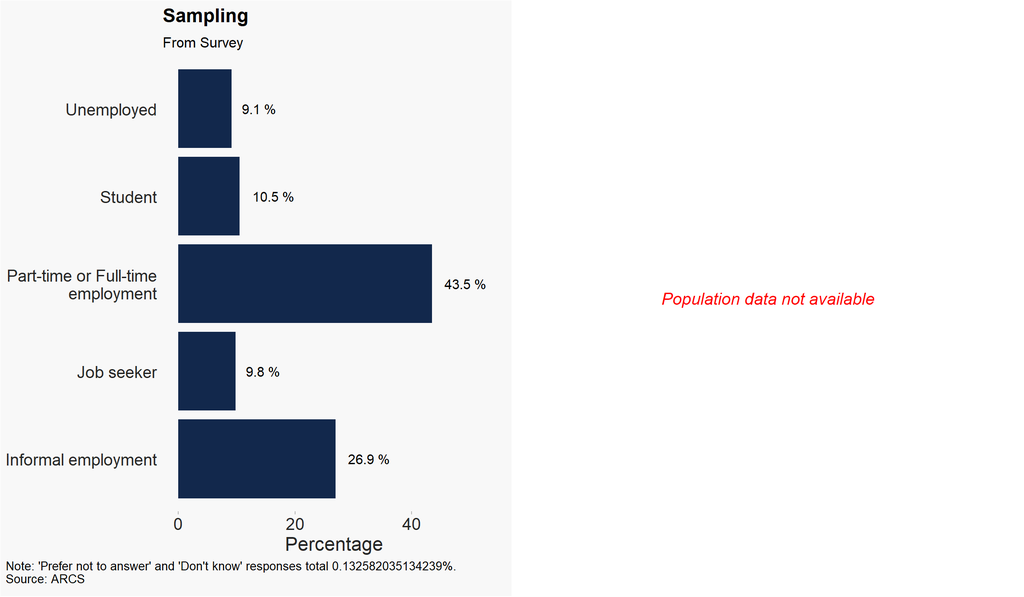

## Limitations

According to the provided information, the survey was mainly conducted at ARCS-organised events, which can be seen in the GPS coordinates (rounded to one digit of longitude and latitude), which indicate many local clusters and and focus mainly on cities.

Overall, such sampling approach ensures familiarity with the ARCS, but also comes with the danger of biasing results, in particular social-desirability bias. It is important to note that this non-probability design does not allow for inferences to be made about the general population in Argentina. Therefore, all the data should be regarded as indicative, and it is strongly advised against presenting this data as representative of the entire country of Argentina, as the convenience sampling approach taken does not allow for drawing generalizations for the population in Argentina.

However, a post-stratification technique can be employed to ensure that the weighted sample corresponds to some features of the population more closely. Therefore, a initial analysis focuses on a few demographic parameters of our sample and compares them to the overall population in the country.

# Survey Results

The charts below present the survey answers as percentages, offering visualization of the Community Trust levels by subdimensions. They illustrate the distribution of community’s perceptions of the competencies and values.

## Perception of trust

### Competencies

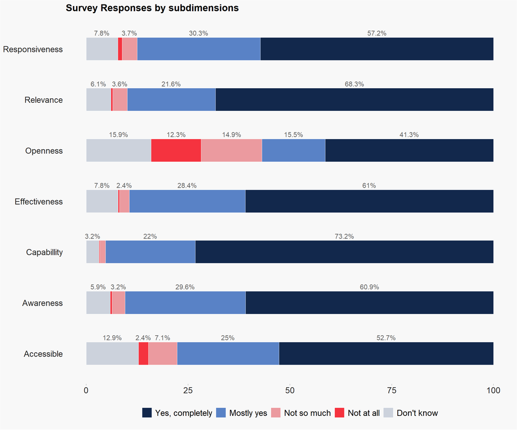

### Values

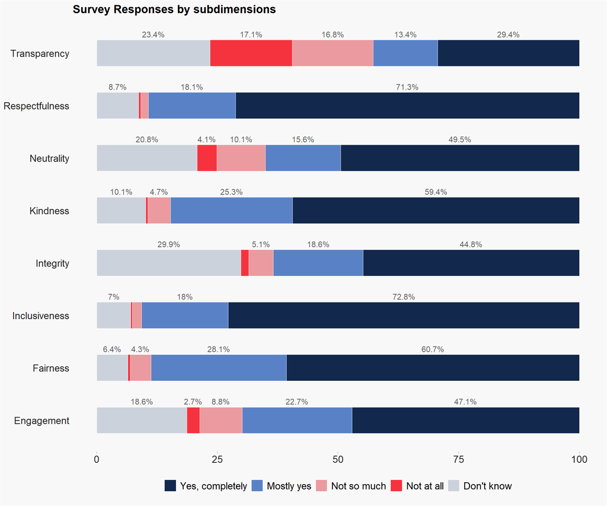

## Contextual questions

This section presents findings on community members’ experiences with and behaviors toward the Red Cross. These questions explore interactions, perceptions, and engagement patterns, offering insights into how the Red Cross is viewed and utilized within the community.

### Experiences

Survey data shows that 81% of respondents have never volunteered for ARCS, while 18.6% have. Additionally, 75.5% have never received aid or support from ARCS, compared to 24.4% who have. This indicates a significant portion of the population is not engaged with or benefiting from these organizations.

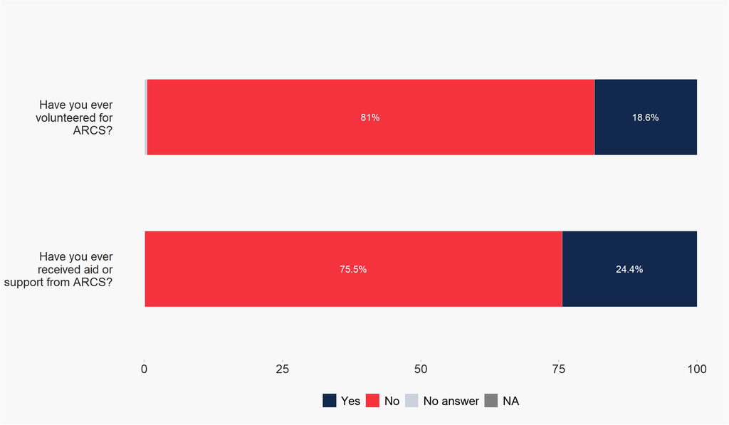

### Behaviours

Survey data indicates that 51.5% of respondents have recommended ARCS to those in need, while 48.1% have not. Additionally, 59.2% have shared information from ARCS with others, compared to 40.2% who have not. This suggests a positive engagement with ARCS, with over half of respondents actively promoting and disseminating its information.

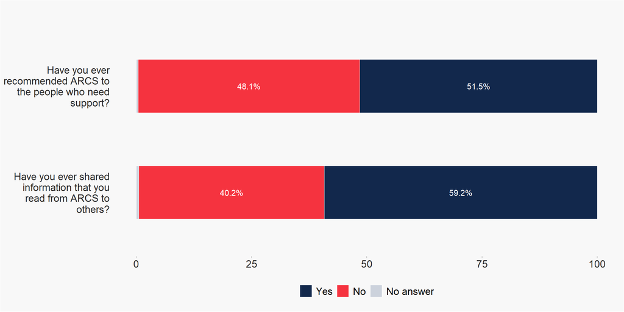

# Score

This score is derived from responses to questions that assess perceptions of competencies and values, providing a comprehensive measure of trust. A higher score indicates stronger trust, suggesting that community members believe their needs are being addressed and their values are respected. *Learn more about scoring method: Methods*

## Overall Score

The chart presents an analysis of competencies and values, each rated on a scale from 0 to 10. In terms of competencies, the highest score is for “Capability” at 9.11, indicating a strong perceived ability in this area. “Openness” scores the lowest at 6.74, suggesting it may be an area for potential improvement. Other competencies such as “Awareness” (8.65) and “Effectiveness” (8.71) also score relatively high.

For values, “Inclusiveness” and “Respectfulness” both score the highest at 9.13, reflecting strong positive perceptions in these areas. “Transparency” is the lowest-scoring value at 5.65, indicating a potential area for enhancement. Other values like “Fairness” (8.59) and “Kindness” (8.61) are also rated highly.

Overall, the data suggests that while there are strong perceptions of capability, inclusiveness, and respectfulness, there is room for improvement in openness and transparency.

*Learn more about weighting process: Weighting*

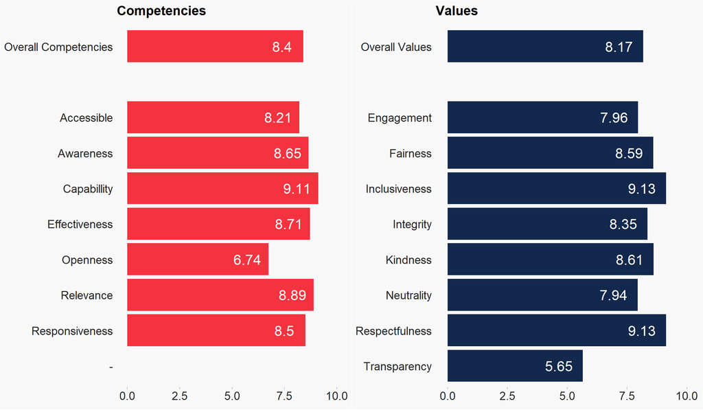

## Score by factors

The chart illustrates perceived competencies and values across various demographics, including age, gender, education, and region. It evaluates how different groups rate attributes like effectiveness and engagement, providing insights into strengths and areas for improvement, helping stakeholders tailor their approaches to diverse population needs.

*Distribution of mean scores for values and competencies per demographic questions*

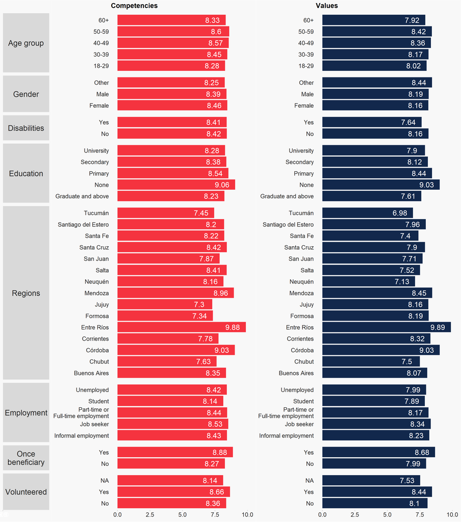

## Score by respondent profile

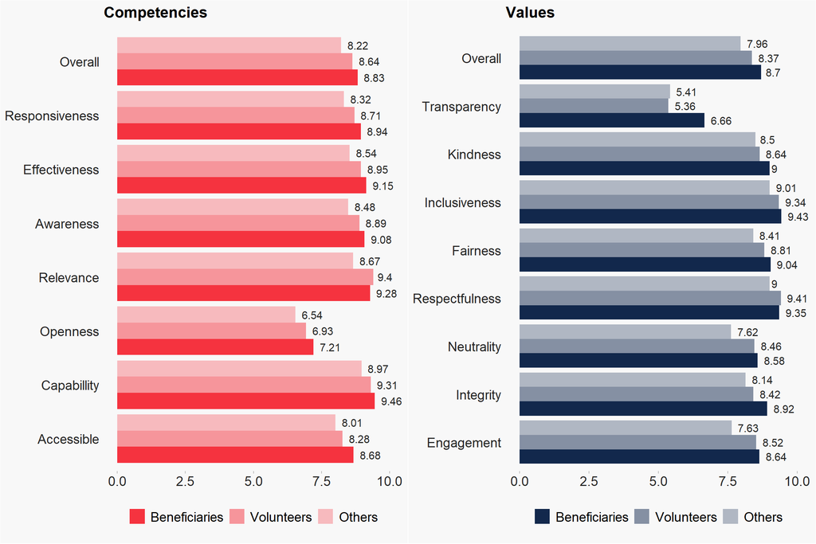

# Methods and Metrics

## Metrics

### Gender

Respondents by Gender

| Gender | Total Respondents | Percentage (%) |
| --- | --- | --- |
| Female | 1678 | 55.6 |
| Male | 1247 | 41.3 |
| Other or did not answer | 92 | 3.0 |
| Total | 3017 | 100.0 |

### Age

Respondents by Age Group

| Age Group | Total Respondents | Percentage (%) |
| --- | --- | --- |
| 18-29 | 1073 | 35.6 |
| 30-39 | 712 | 23.7 |
| 40-49 | 585 | 19.4 |
| 50-59 | 358 | 11.9 |
| 60+ | 282 | 9.4 |

### Geographic

Respondents by Location and Region

| Region | Location | Total Respondents | Percentage (%) |
| --- | --- | --- | --- |
| Buenos Aires | TOTAL | 1162 | 100.0 |
| Buenos Aires | Mar del Plata | 217 | 18.7 |
| Buenos Aires | Bahía Blanca | 195 | 16.8 |
| Buenos Aires | La Plata | 178 | 15.3 |
| Buenos Aires | Saavedra | 150 | 12.9 |
| Buenos Aires | Santos Lugares | 94 | 8.1 |
| Buenos Aires | Tandil | 74 | 6.4 |
| Buenos Aires | Almirante Brown | 70 | 6.0 |
| Buenos Aires | Luján | 57 | 4.9 |
| Buenos Aires | Campana | 56 | 4.8 |
| Buenos Aires | Villa Domínico | 34 | 2.9 |
| Buenos Aires | Siglo 21 | 26 | 2.2 |
| Buenos Aires | Azul | 8 | 0.7 |
| Buenos Aires | San Isidro | 2 | 0.2 |
| Buenos Aires | Sede Central | 1 | 0.1 |
| Chubut | TOTAL | 21 | 100.0 |
| Chubut | Comodoro Rivadavia | 21 | 100.0 |
| Corrientes | TOTAL | 144 | 100.0 |
| Corrientes | Corrientes | 141 | 97.9 |
| Corrientes | Córdoba | 3 | 2.1 |
| Córdoba | TOTAL | 466 | 100.0 |
| Córdoba | Río Cuarto | 303 | 65.0 |
| Córdoba | Córdoba | 142 | 30.5 |
| Córdoba | Siglo 21 | 21 | 4.5 |
| Entre Ríos | TOTAL | 169 | 100.0 |
| Entre Ríos | Gualeguay | 168 | 99.4 |
| Entre Ríos | Don Torcuato | 1 | 0.6 |
| Formosa | TOTAL | 37 | 100.0 |
| Formosa | Clorinda | 36 | 97.3 |
| Formosa | Corrientes | 1 | 2.7 |
| Jujuy | TOTAL | 73 | 100.0 |
| Jujuy | Jujuy | 73 | 100.0 |
| Mendoza | TOTAL | 114 | 100.0 |
| Mendoza | San Rafael | 110 | 96.5 |
| Mendoza | Siglo 21 | 4 | 3.5 |
| Misiones | TOTAL | 9 | 100.0 |
| Misiones | Siglo 21 | 8 | 88.9 |
| Misiones | La Plata | 1 | 11.1 |
| Neuquén | TOTAL | 18 | 100.0 |
| Neuquén | Siglo 21 | 15 | 83.3 |
| Neuquén | Saavedra | 2 | 11.1 |
| Neuquén | San Rafael | 1 | 5.6 |
| No data | TOTAL | 1 | 100.0 |
| No data | Bahía Blanca | 1 | 100.0 |
| Salta | TOTAL | 88 | 100.0 |
| Salta | Salta | 56 | 63.6 |
| Salta | Siglo 21 | 31 | 35.2 |
| Salta | Santiago del Estero | 1 | 1.1 |
| San Juan | TOTAL | 78 | 100.0 |
| San Juan | San Juan | 78 | 100.0 |
| Santa Cruz | TOTAL | 51 | 100.0 |
| Santa Cruz | Río Gallegos | 49 | 96.1 |
| Santa Cruz | Siglo 21 | 2 | 3.9 |
| Santa Fe | TOTAL | 409 | 100.0 |
| Santa Fe | Esperanza | 174 | 42.5 |
| Santa Fe | Rosario | 113 | 27.6 |
| Santa Fe | Venado Tuerto | 109 | 26.7 |
| Santa Fe | Siglo 21 | 12 | 2.9 |
| Santa Fe | Corrientes | 1 | 0.2 |
| Santiago del Estero | TOTAL | 32 | 100.0 |
| Santiago del Estero | Santiago del Estero | 31 | 96.9 |
| Santiago del Estero | Siglo 21 | 1 | 3.1 |
| Tucumán | TOTAL | 145 | 100.0 |
| Tucumán | San Miguel de Tucumán | 143 | 98.6 |
| Tucumán | Siglo 21 | 2 | 1.4 |

### Relationship with RC

Respondents by relationship with RC

| Profile | Total Respondents |
| --- | --- |
| Aid recipient | 737 |
| Volunteer | 574 |
| Other | 1945 |

## Methods

**Scoring methodology**

To determine the score, we employ the following method:

1. Survey Structure The CTI survey includes multiple questions grouped under sub-dimensions of two main categories:
   - Competencies (e.g., reliability, effectiveness, technical proficiency)
   - Values (e.g., ethics, integrity, fairness, transparency)
2. Sub-Dimension Scoring

   Each sub-dimension comprises several survey items (questions).Respondents answer on a Likert-type scale (1 to 4 - Don’t not is excluded). For each sub-dimension:

   *Sub-dimension Score = ∑ (Weighted Response Scores) / Number of Items*

If weights are not empirically derived, equal weighting is typically applied to each item.

3. Dimension Scoring

Once all sub-dimension scores are calculated, the Competency Score and Values Score are each derived as the arithmetic mean of their respective sub-dimension scores:

- *Competency Score = ∑(Sub-dimension Scores for Competency) /𝑛*
- *Values Score = ∑(Sub-dimension Scores for Values)/𝑚*

where 𝑛 and 𝑚 are the number of sub-dimensions in each category.

4. Overall Scoring

   The final Community Trust Index score is the arithmetic mean of the Competency and Values scores:
- *CTI Score = (Competency Score + Values Score)/2*

## Weighting

**Weighting vs. unweighting**

To correct demographic deviations from the overall population, we applied a technique called raking. This method adjusts results based on variables such as age, gender, province, and education level to align our sample with the population distribution. Data sources included UN statistics for age and gender, 2022 provincial data, and OECD data for education levels. For the student population, we estimated approximately 6% using 2020 data.

The weighted results show slightly smaller means, with minimal differences from unweighted data, except for the openness question, which shows a slightly larger decrease in the overall mean value.

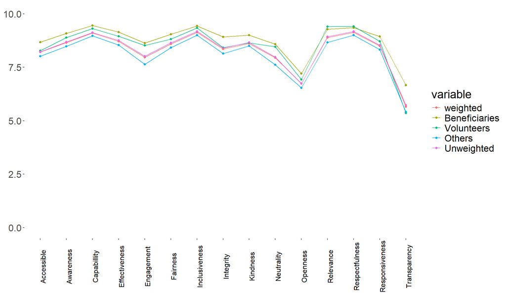

## Drivers Correlation

**Correlation matrix**

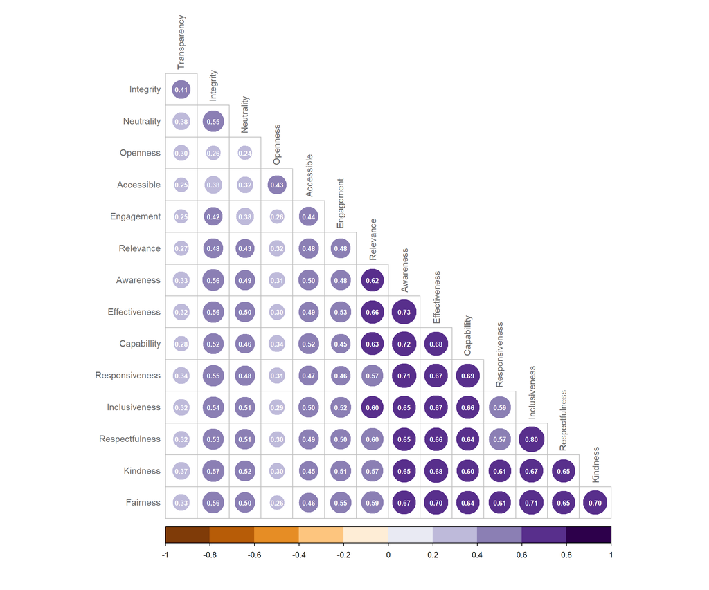

## Significance testing

**Significance testing**

| Dimension | Drivers | Volunteer-Other | Volunteer-Beneficiary | Benficiary-Other |
| --- | --- | --- | --- | --- |
| Competency | Capabillity | Yes | No | Yes |
| Competency | Responsiveness | Yes | Yes | Yes |
| Competency | Awareness | Yes | No | Yes |
| Competency | Accessible | No | Yes | Yes |
| Competency | Openness | Yes | No | Yes |
| Competency | Relevance | Yes | No | Yes |
| Competency | Effectiveness | Yes | Yes | Yes |
| Value | Kindness | No | Yes | Yes |
| Value | Fairness | Yes | No | Yes |
| Value | Inclusiveness | Yes | No | Yes |
| Value | Respectfulness | Yes | No | Yes |
| Value | Engagement | Yes | No | Yes |
| Value | Integrity | No | Yes | Yes |
| Value | Transparency | No | Yes | Yes |
| Value | Neutrality | Yes | No | Yes |

# Download

Download Summary Excel File